# DATA 607 - Tidyverse CREATE

Eddie Xu

2023-04-12

## TIDYVERSE CREATE ASSIGNMENT

This assignment will be create a vignette about one of TIDYVERSE libraries, ggplot. Other libraries of the tidyverse will be used for data wrangling. In this case, a dataset from kaggle (https://www.kaggle.com/datasets/arnabchaki/popular-video-games-1980-2023?resource=download) will be used to demonstrates the capacity of data visualization in R Studio.

## Load Packages

```r
library(tidyverse)
library(lubridate)
```

## Load Dataset

The dataset contains popular video games titles from 1980 to 2023.

```r
# read. csv and load the dataset
raw_file <- "https://raw.githubusercontent.com/eddiexunyc/SPRING2023TIDYVERSE/exu/games.csv"
raw_dataset <- read.csv(raw_file)

head(raw_dataset)
```

```
##   X                                   Title Release.Date
## 1 0                              Elden Ring Feb 25, 2022
## 2 1                                   Hades Dec 10, 2019
## 3 2 The Legend of Zelda: Breath of the Wild Mar 03, 2017
## 4 3                               Undertale Sep 15, 2015
## 5 4                           Hollow Knight Feb 24, 2017
## 6 5                               Minecraft Nov 18, 2011
##                                                  Team Rating Times.Listed
## 1      ['Bandai Namco Entertainment', 'FromSoftware']    4.5         3.9K
## 2                                ['Supergiant Games']    4.3         2.9K
## 3 ['Nintendo', 'Nintendo EPD Production Group No. 3']    4.4         4.3K
## 4                                  ['tobyfox', '8-4']    4.2         3.5K
## 5                                     ['Team Cherry']    4.4           3K
## 6                                  ['Mojang Studios']    4.3         2.3K
##   Number.of.Reviews                                               Genres
```

[output cut: 27 more lines]

## Data Clean up

By using dplyr package for data wrangling, the data can be cleaned up and be perpared for data visualization.

```r
# Convert "K" into 1000 and the data type to numeric
raw_dataset$Number.of.Reviews <- as.numeric(gsub("K", "e3", raw_dataset$Number.of.Reviews))

# Convert Release Date into date data type through the lubridate package
raw_dataset$Release.Date <- mdy(raw_dataset$Release.Date)
# sort the data based on the rating
video_game_data <- raw_dataset %>%
  arrange(desc(raw_dataset$Rating))

head(video_game_data)
```

```
##      X                             Title Release.Date
## 1 1252 Elden Ring: Shadow of the Erdtree         <NA>
## 2   28      Disco Elysium: The Final Cut   2020-05-01
## 3   43                       Outer Wilds   2019-05-28
## 4  139                     Disco Elysium   2019-10-15
## 5  252      Umineko: When They Cry Chiru   2009-09-15
## 6  297       Bloodborne: The Old Hunters   2015-11-24
##                                              Team Rating Times.Listed
## 1  ['FromSoftware', 'Bandai Namco Entertainment']    4.8           18
## 2                                       ['ZA/UM']    4.6         1.1K
## 3     ['Mobius Digital', 'Annapurna Interactive']    4.6         1.8K
## 4                                       ['ZA/UM']    4.6         1.1K
## 5                              ['07th Expansion']    4.6          324
## 6 ['FromSoftware', 'Sony Computer Entertainment']    4.6          266
##   Number.of.Reviews                                        Genres
```

[output cut: 27 more lines]

## Data Visualization

With data clean up, the data will be analyzed and presented with a visual for better presentation for audiences.

## Top 10

Let start with the top 10 popular games in the past 40 years.

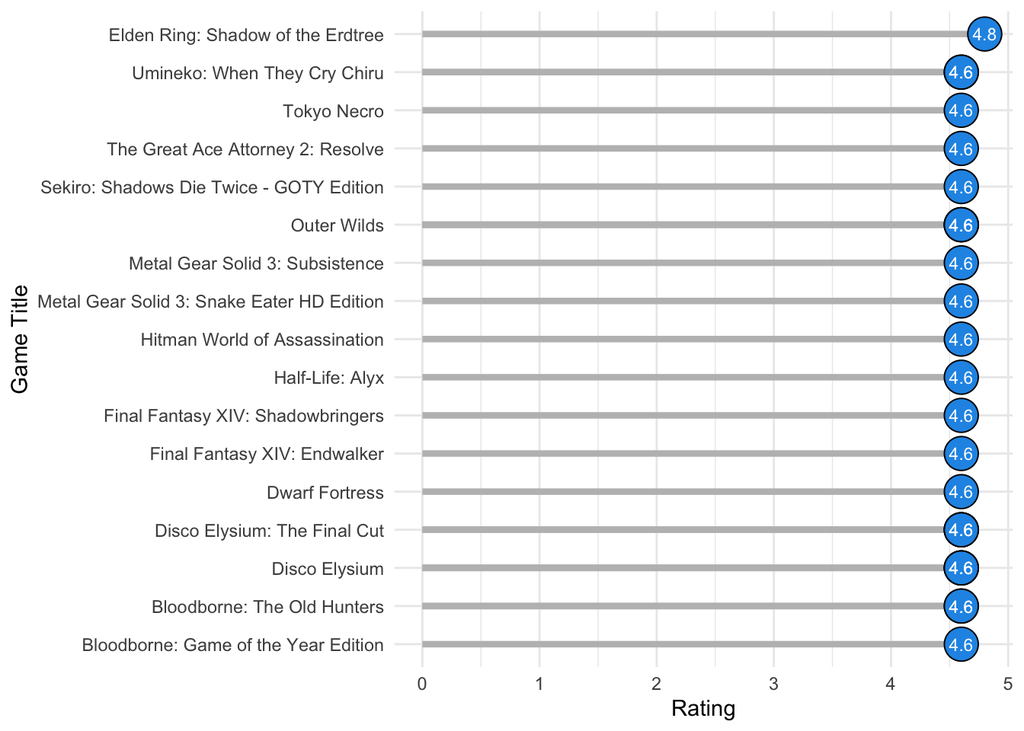

```r
# find the top 10 games based on the rating
top_10_game <- video_game_data %>%
  slice_max(video_game_data$Rating, n = 10)

# top 10 lolipop chart
ggplot(top_10_game, aes(x = reorder(`Title`, `Rating`), y = `Rating`)) +
  geom_segment(aes(x = reorder(`Title`, `Rating`), xend = reorder(`Title`, `Rating`), y = 0, yend = `Rating`), color = "gray", lwd = 1.5) +
  geom_point(size = 7.5, pch = 21, bg = 4, col = 1) +
  geom_text(aes(label = `Rating`), color = "white", size = 3) +
  xlab("Game Title") +
  ylab("Rating") +
  coord_flip() +
  theme_minimal()
```

Based on the graph, The game, “Elden Ring: Shadow of the Erdtree”, have the highest rating.

## Bottom 10

Now let’s see the bottom 10 games.

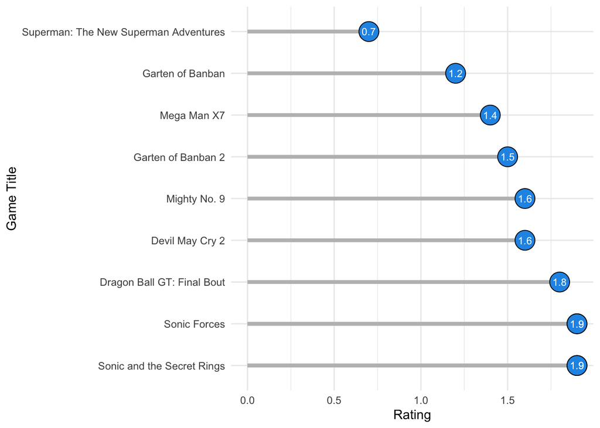

```r
# find the top 10 games based on the rating
bottom_10_game <- video_game_data %>%
  slice_min(video_game_data$Rating, n = 10)

# bottom 10 lolipop chart
ggplot(bottom_10_game, aes(x = reorder(`Title`, -`Rating`), y = `Rating`)) +
  geom_segment(aes(x = reorder(`Title`, -`Rating`), xend = reorder(`Title`, -`Rating`), y = 0, yend = `Rating`), color = "gray", lwd = 1.5) +
  geom_point(size = 7.5, pch = 21, bg = 4, col = 1) +
  geom_text(aes(label = `Rating`), color = "white", size = 3) +
  xlab("Game Title") +
  ylab("Rating") +
  coord_flip() +
  theme_minimal()
```

On the bottom end, the game with the lowest rating is “Superman: The New Superman Adventures”

## Popular Games throughout the Year

With so many popular video games released every year, let’ see how many games were released in every year.

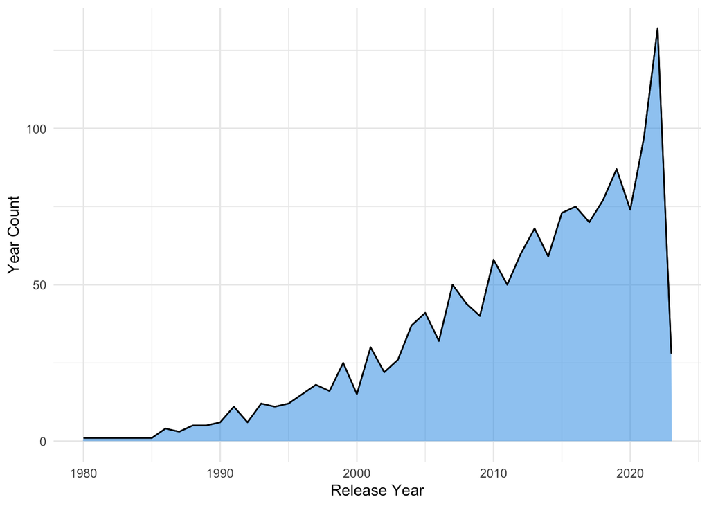

```r
# calculate the total count of popular video games each year
vg_year_count <- video_game_data %>%
  mutate(release_year = as.numeric(format(video_game_data$Release.Date, "%Y"))) %>%
  drop_na() %>%
  group_by(release_year) %>%
  summarise(year_count = n())

colnames(vg_year_count) <- c("Release Year", "Year Count")


# line graph
ggplot(vg_year_count, aes(x = `Release Year`, y = `Year Count`)) +
  geom_line() +
  geom_area(fill = 4,
            alpha = 0.5,
            color = 1,
            lwd = 0.5,
            linetype = 1) +
  theme_minimal()
```

As we can see the trend, there are a lot of popular video games released in the 2010s era. From there, we should find out which year have the most popular video games released.

```r
vg_year_count <- vg_year_count %>%
  arrange(desc(vg_year_count$`Year Count`))

head(vg_year_count)
```

```
## # A tibble: 6 × 2
##   `Release Year` `Year Count`
##            <dbl>        <int>
## 1           2022          132
## 2           2021           97
## 3           2019           87
## 4           2018           77
## 5           2016           75
## 6           2020           74
```

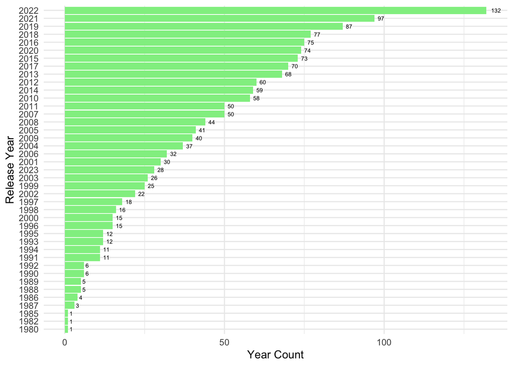

```r
# bar graph
ggplot(vg_year_count, aes(reorder(x = `Release Year`, `Year Count`), y = `Year Count`)) +
  geom_bar(stat = "identity", fill = "lightgreen") +
  geom_text(aes(label = `Year Count`),
            vjust = 0.5,
            hjust = -0.5,
            color = "black",
            size = 2) +
  coord_flip() +
  xlab("Release Year") +
  theme_minimal()
```

It shows that 2022 was the biggest year with 132 video games released. Compared to other years with the lowest video games released, it is a hug difference.

## Conclusion

With ggplot, we can see how visualizations provide better understanding of the data.